# Rogers_HW9

##### Exercise 8.19 (Penguins: estimation)

1. The Normal-Normal model is appropriate here. Both because the mu gives it away, and also because we can expect a range of flipper lengths to be normally distributed (like height)
2. Prior: 200, from 140 to 260

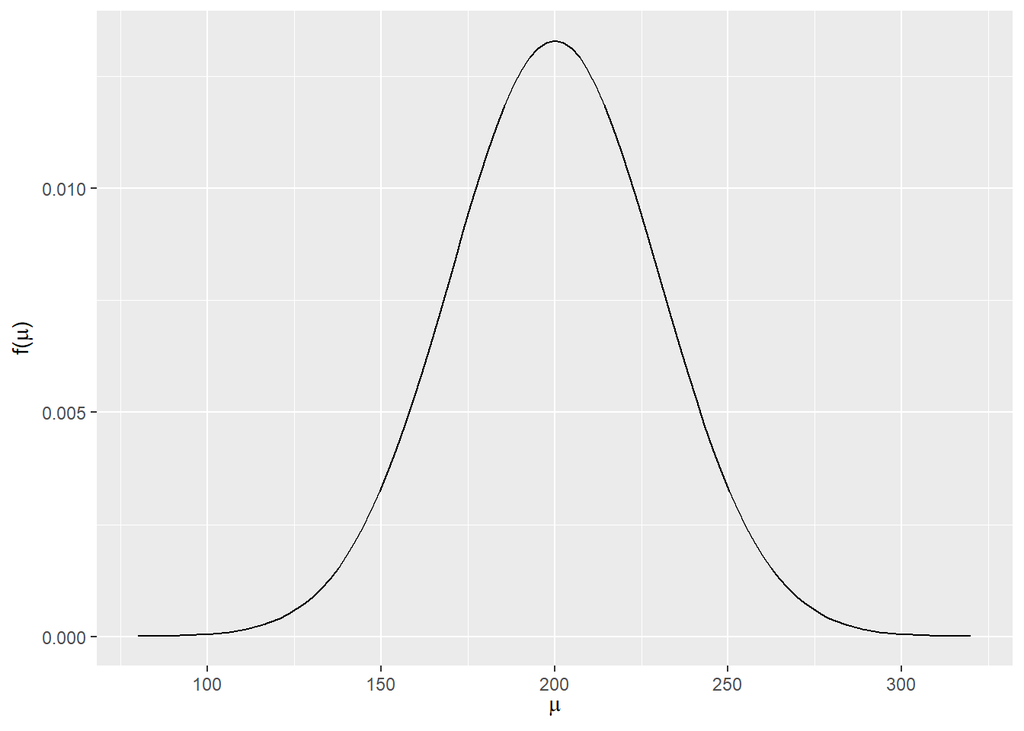

```r
plot_normal(200, 30)
```

That looks good. So Normal(200, 30) (I don’t actually know the syntax here, is it normal or mu or something else?)

3. How many data points are there for Adelie and what’s the sample mean

```r
data("penguins_bayes")
filter(penguins_bayes, species == "Adelie") |>
nrow()
```

```
## [1] 152
```

```r
penguins_bayes |>
  filter(species == "Adelie") |>
  summarize(adelie_mean = mean(flipper_length_mm, na.rm = TRUE), adelie_sd = sd(flipper_length_mm, na.rm = TRUE))
```

```
## # A tibble: 1 x 2
##   adelie_mean adelie_sd
##         <dbl>     <dbl>
## 1        190.      6.54
```

```r
qnorm(c(.025, .975), 189.9536, 6.539457)
```

```
## [1] 177.1365 202.7707
```

##### Exercise 8.20 (Penguins: hypothesis testing)

1. You hypothesize that the average Adelie flipper length is somewhere between 200mm and 220mm

H0 : 220 < mu < 200 Ha : 220 > mu > 200

2. What decision do you make about these hypotheses given the previous CI?

The alternate hypothesis looks likely to be unlikely, a majority of CI values fell below 200

3. Calculate and interpret the posterior probability that your hypothesis is true

```r
pnorm(c(200, 220), 189.9536, 6.539457)
```

```
## [1] 0.9377644 0.9999978
```

So obviously this part or an earlier part of the exercise are incorrect. Or both.

4. Explain your conclusion about mu

Well our hypothesis was either spot on or exactly off…

##### Exercise 8.21 (Loons: estimation)

1. The gamma-poisson model is appropriate here, both because lambda gives it away, and also because we’re looking at occurrences over time
2. Our prior understanding is that we have about 2 sightings per time period, with an SD of 1

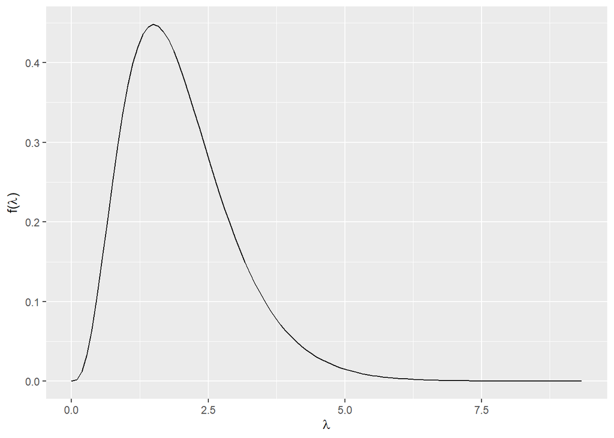

```r
# looking for gamma distributions which represent our prior

plot_gamma(4, 2)
```

```r
summarize_gamma(4, 2)
```

```
##   mean mode var sd
## 1    2  1.5   1  1
```

That took a lot of guess and check. Is that the only way to do this?

```r
data("loons")
```

```r
loons |>
  summarize(loon_sum = sum(count, na.rm = TRUE),
            loon_mean = mean(count, na.rm = TRUE),
            loon_sd = sd(count, na.rm = TRUE))
```

```
## # A tibble: 1 x 3
##   loon_sum loon_mean loon_sd
##      <dbl>     <dbl>   <dbl>
## 1       53      2.94    2.75
```

So our total number of loons sighted is 53. It’s unclear to me if that is our count of data points as well? We also have 18 data points as rows.

4. Calculate a middle 95% posterior CI

```r
# calculating posterior
summarize_gamma_poisson(4, 2, 53, 18)
```

```
##       model shape rate mean mode    var        sd
## 1     prior     4    2 2.00  1.5 1.0000 1.0000000
## 2 posterior    57   20 2.85  2.8 0.1425 0.3774917
```

```r
qnorm(c(.025, .975), 57, 20)
```

```
## [1] 17.80072 96.19928
```

This feels wrong.

Okay I figured it out. I was using qnorm instead of qgamma

```r
qgamma(c(.025, .975), 57, 20)
```

```
## [1] 2.158562 3.636033
```

I feel like this still doesn’t make sense.

Okay. So I didn’t look closely at the data frame when starting this problem. I was using count, which is across the year, but this exercise is looking for count per 100, which is a different variable. Starting (c) and (d) over…

```r
loons |>
  summarize(loon_sum = sum(count_per_100, na.rm = TRUE),
            loon_mean = mean(count_per_100, na.rm = TRUE),
            loon_sd = sd(count_per_100, na.rm = TRUE))
```

```
## # A tibble: 1 x 3
##   loon_sum loon_mean loon_sd
##      <dbl>     <dbl>   <dbl>
## 1       27       1.5    1.58
```

```r
summarize_gamma_poisson(4, 2, 27, 18)
```

```
##       model shape rate mean mode    var        sd
## 1     prior     4    2 2.00  1.5 1.0000 1.0000000
## 2 posterior    31   20 1.55  1.5 0.0775 0.2783882
```

```r
# now we're getting somewhere!
```

```r
qgamma(c(.025, .975), 31, 20)
```

```
## [1] 1.053150 2.141343
```

!!!

##### Exercise 8.22 (Loons: hypothesis testing)

1. H0: lambda >= 1 Ha: lambda < 1

The null hypothesis seems quite likely, as the 95% CI has a lower limit of 1.053

3. Test the posterior probability that lambda < 1

```r
post_prob <- pgamma(.999999, 31, 20)
post_prob
```

```
## [1] 0.01347451
```

I’m not sure how else to signal less than 1 in the pgamma function, but I think this works, and makes sense, it gives quite a low probability.

Putting this all together, I am strongly in favor of the null hypothesis.

##### Exercise 8.23 (Loons with MCMC: simulation)

1. Simulate the posterior model of lambda, 4 chains, 10000 iterations per chain

```r
loon_model <-
"
data {

  int<lower = 0> Y[18];



}

parameters {

  real<lower = 0> lambda;

}

model {

  Y ~ poisson(lambda);
  lambda ~ gamma(4, 2);

}


"
```

```r
counts <- loons |>
  mutate(count_per_100)
```

I tried a bunch of different ways to wrangle the data to isolate the count_per_100 variable so I can include it as a vector, and I just can’t seem to get it. This is a problem that I’ve run into several times. I want to understand this better

```r
loons_sim <- stan(model_code = loon_model, data = list(Y = c(0, 0, 0, 0, 0, 0, 0, 1, 1, 1, 2, 2, 2, 3, 3, 3, 4, 5),
     chains = 4, iter = 5000*2                                                  ))
# I acknowledge that this is absolutely ridiculous, but I do think it's a valid simulation
```

2. perform some MCMC diagnostics

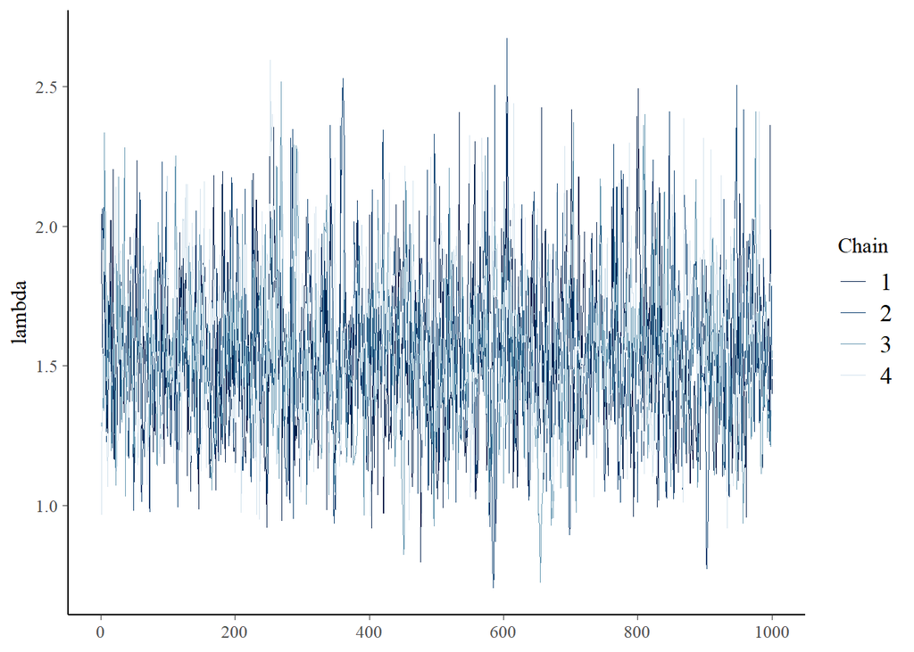

```r
mcmc_trace(loons_sim, pars = "lambda")
```

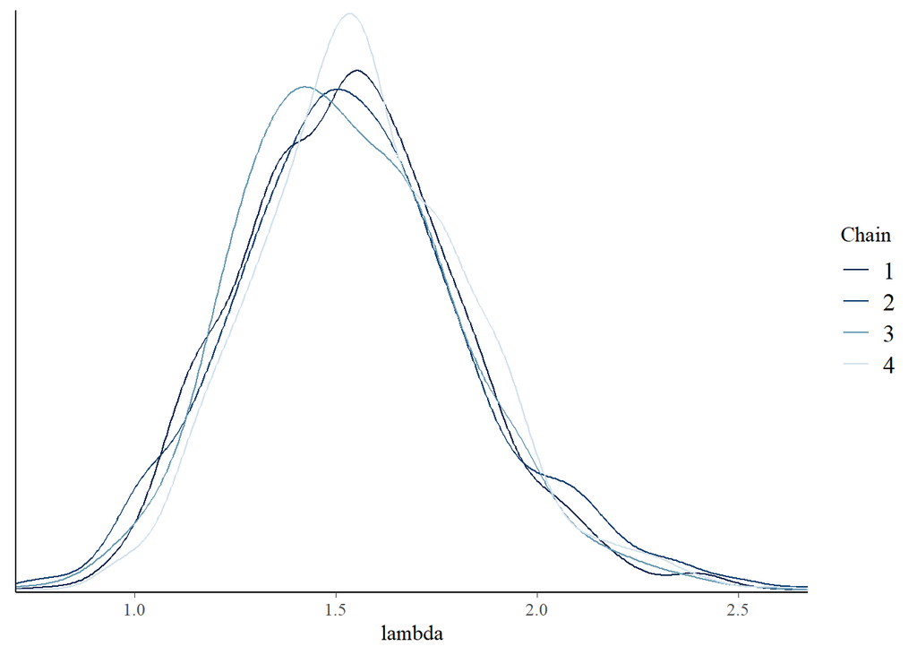

```r
mcmc_dens_overlay(loons_sim, pars = "lambda")
```

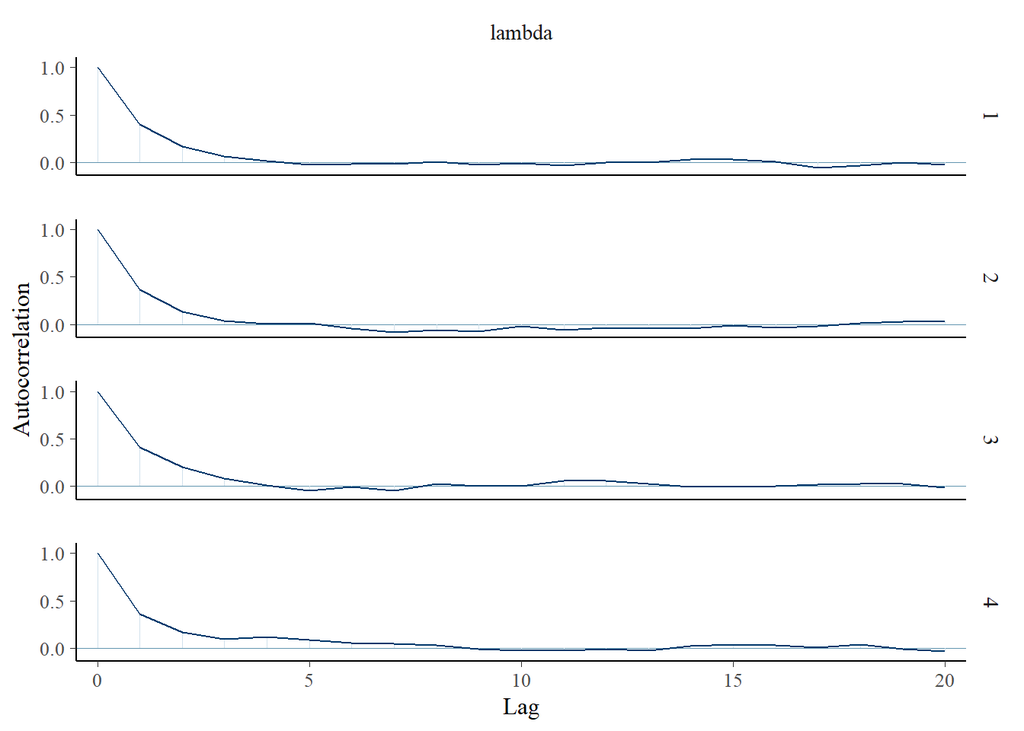

```r
mcmc_acf(loons_sim, pars = "lambda")
```

The chains are well mixed and show healthy correlation!

3. approximate a middle CI for lambda

```r
tidy(loons_sim, conf.int = TRUE, conf.level = .95)
```

```
## # A tibble: 1 x 5
##   term   estimate std.error conf.low conf.high
##   <chr>     <dbl>     <dbl>    <dbl>     <dbl>
## 1 lambda     1.53     0.279     1.05      2.15
```

```r
loons_df <- as.data.frame(loons_sim, pars = "lp__", include = FALSE)
```

```r
loons_df |>
  summarize(lower_95 = quantile(lambda, .025),
            upper_95 = quantile(lambda, .975))
```

```
##   lower_95 upper_95
## 1 1.046591 2.152515
```

4. Use MCMC simulation to approximate the posterior probability that lambda < 1

```r
loons_df |>
  mutate(under_one = lambda < 1) |>
  tabyl(under_one)
```

```
##  under_one    n percent
##      FALSE 3940   0.985
##       TRUE   60   0.015
```

As with the previous exercise, the simulation and actual posterior are near indistinguishable!